# mape_r-01: reto #1

Andree Valle-Campos

13/2/2020

# 1 objetivo

- **Crear un mapa con la georeferenciación de casos de coranovirus nCov-2019 en China.**

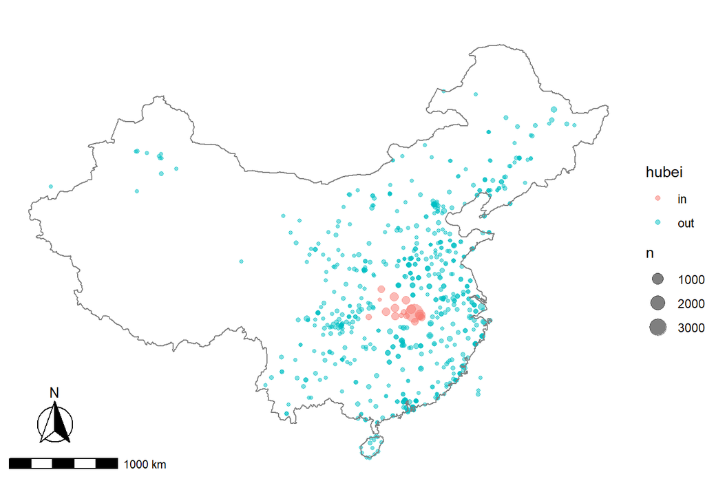

- Si quieres seguir jugando **:)** , envía tu avance (hasta donde hayas podido llegar, nomás)
- **¿qué enviar?** un copia y pega de los comandos escritos, de tal forma que al pegarlos en la consola se ejecute tu avance.
- **fecha límite:** jueves 20 de febrero del 2020 al mediodía (hora peruana) al correo `avallecam@gmail.com` con el tema: `mape_r-01_reto`

# 2 indicaciones

> - lee cada uno de los pasos acá listados
> - usa la clase, la pista y referencias para poder cumplir con los pasos
> - puedes usar la sesión del **rstudio.cloud** para ejecutar esta actividad

## 2.1 importar base con `read_rds`

Algunos detalles:

- invoca los paquetes `tidyverse` y `sf`
- el nombre de la base es `ncovdb_china.rds`
- la base ya está alojada en el **rstudio.cloud** (ver link en página web)
- también podrás descargarla acceciendo al siguiente [link](https://github.com/avallecam/spclustr/raw/master/ncovdb_china.rds)

## 2.2 contar casos por provincia y ubicación con `count`

- `hubei`: categórica dicotómica **in** o **out**,
- `latitude` y
- `longitude`

Puedes usar `glimpse` para visualizar el contenido completo de la base.

```
## # A tibble: 693 x 4
##    hubei latitude longitude     n
##    <chr>    <dbl>     <dbl> <int>
##  1 in        30.6      114.  3794
##  2 in        30.5      115.   719
##  3 in        30.9      114.   523
##  4 in        32.0      112.   380
##  5 in        30.7      111.   341
##  6 in        31.7      113.   311
##  7 in        31.0      112.   301
##  8 in        30.3      112.   253
##  9 in        30.4      115.   251
## 10 in        30.2      115.   219
## # ... with 683 more rows
```

## 2.3 transformar a formato `sf` con `geometry`

- usa `crs = 4610`
- los demás argumentos pueden ser los mismos de la clase

```
## Simple feature collection with 693 features and 4 fields
## Attribute-geometry relationship: 4 constant, 0 aggregate, 0 identity
## geometry type:  POINT
## dimension:      XY
## bbox:           xmin: 76 ymin: 18 xmax: 130 ymax: 50
## epsg (SRID):    4610
## proj4string:    +proj=longlat +a=6378140 +b=6356755.288157528 +no_defs
## # A tibble: 693 x 5
##    hubei latitude longitude     n    geometry
##    <chr>    <dbl>     <dbl> <int> <POINT [°]>
##  1 in        30.6      114.  3794    (114 31)
##  2 in        30.5      115.   719    (115 30)
##  3 in        30.9      114.   523    (114 31)
##  4 in        32.0      112.   380    (112 32)
##  5 in        30.7      111.   341    (111 31)
##  6 in        31.7      113.   311    (113 32)
##  7 in        31.0      112.   301    (112 31)
##  8 in        30.3      112.   253    (112 30)
##  9 in        30.4      115.   251    (115 30)
## 10 in        30.2      115.   219    (115 30)
## # ... with 683 more rows
```

## 2.4 crear ggplot con `geom_sf`

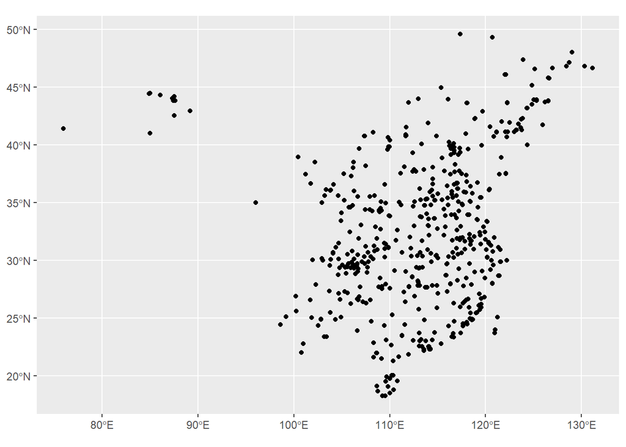

## 2.5 cada punto debe tener un diámetro proporcional a la cantidad de casos (usar `size` dentro de `aes`)

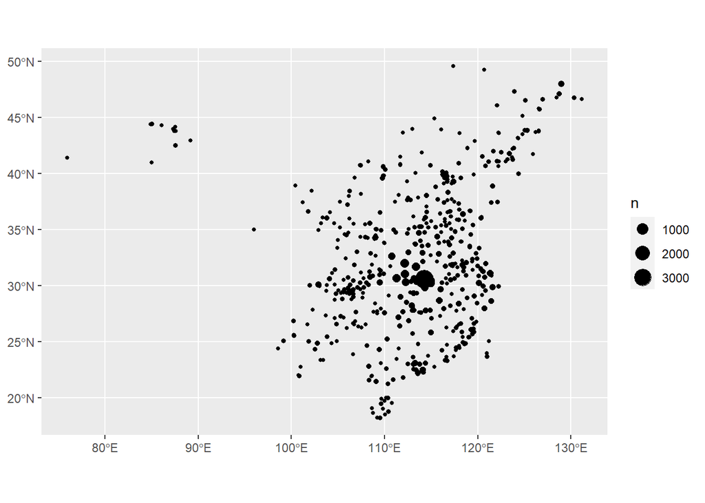

## 2.6 cada punto debe tener un color de pertenecer o no a la provincia de Hubei (usar `color` dentro de `aes`)

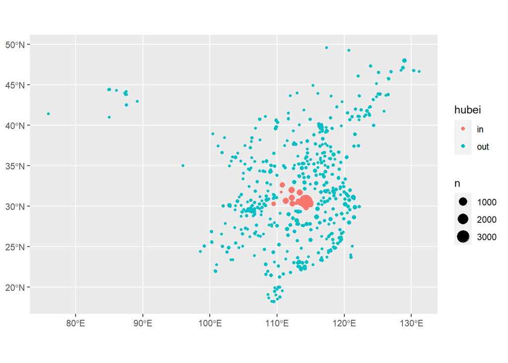

## 2.7 cada punto debe tener una transparencia (usa `alpha = 0.5`)

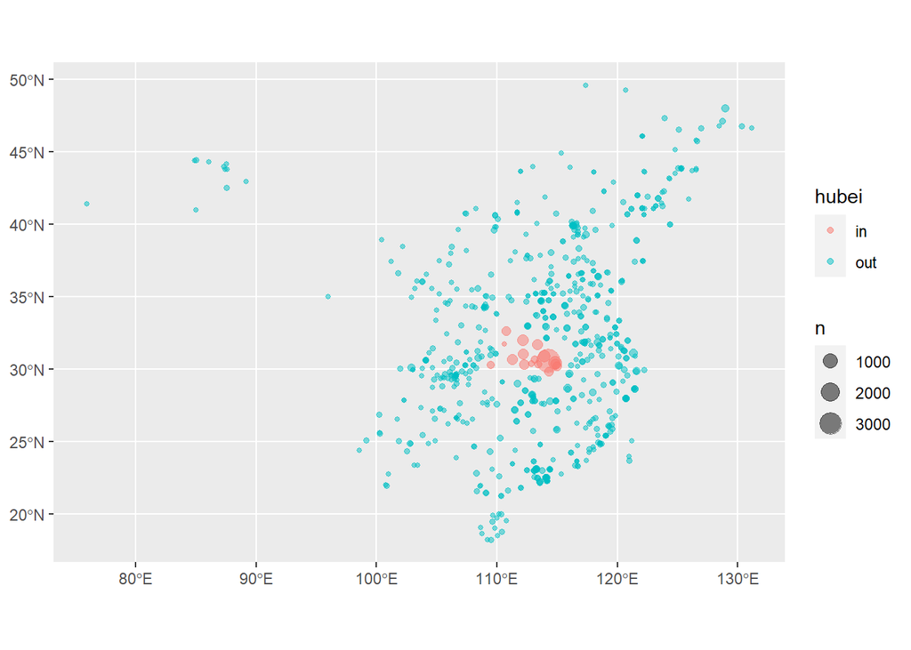

## 2.8 nuevo: agrega el las fronteras de China

Solo debe de agregar esta línea a la cadena de comandos de ggplot

`borders(database = "world",regions = "China")`

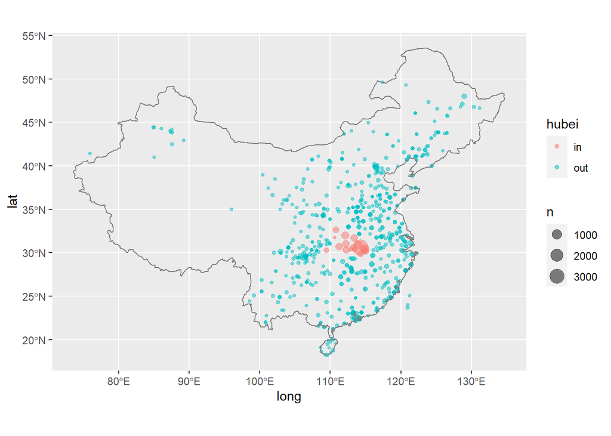

## 2.9 modifica el tema del ggplot con `theme_void()`

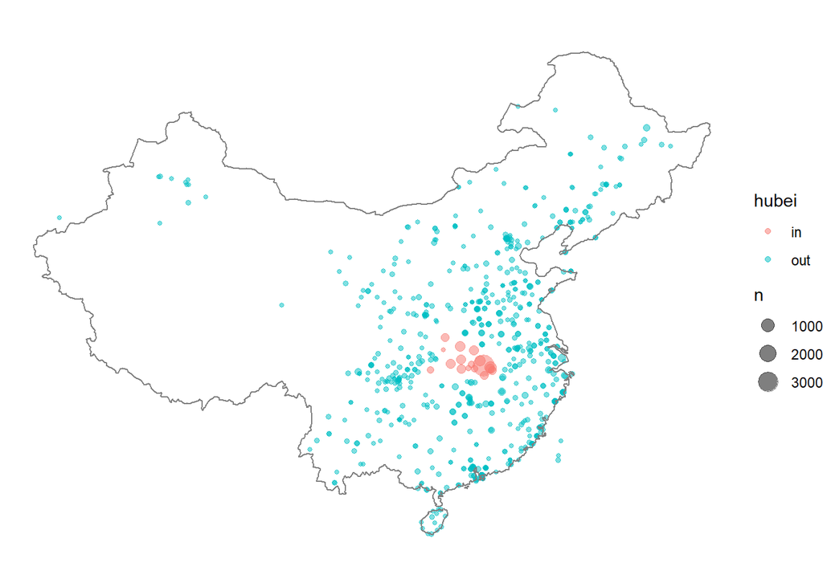

# 3 pista

```r
library(paquete_uno)
library(paquete_dos)

ncovdb_china <- read_xxx("nombre_del_archivo.xxx")

ncovdb_china %>%
  count(variable_uno, variable_dos, variable_tres) %>%
  st_as_sf(argumento_coordinadas = c("aqui_va_longitud", "aqui_va_latitud"),
           argumento_otros = ver_opciones_en_la_clase_anterior) %>%
  ggplot(aes(estetica_uno = variable_uno, estetica_dos = variable_dos)) +
  geom_cual(estetica_tres = un_numero) +
  coord_cual() +
  borders(database = "world",regions = "China") +
  theme_cual()
```

> recuerda que el **pipe** o `%>%` se puede crear con la combinación de teclas **`Ctrl + Alt + M`** (En Mac cambiar `Cmd` por `Ctrl`)

> no olvides usar el **Tab** para aprovechas las opciones de autocompletado de Rstudio

# 4 ¿cómo obtuvimos la base de datos?

```r
# if(!require("tidyverse")) install.packages("tidyverse")
# if(!require("devtools")) install.packages("devtools")
# if(!require("googlesheets4")) devtools::install_github("tidyverse/googlesheets4")
# if(!require("sf")) install.packages("sf")

library(tidyverse)
library(googlesheets4)
library(janitor)
library(sf)

ncovdb_sheetname <- "https://docs.google.com/spreadsheets/d/1itaohdPiAeniCXNlntNztZ_oRvjh0HsGuJXUJWET008/"

ncovdb_in_hubei <- sheets_get(ss = ncovdb_sheetname) %>%
  read_sheet(sheet = "Hubei") %>%
  mutate(hubei="in")

ncovdb_out_hubei <- sheets_get(ss = ncovdb_sheetname) %>%
  read_sheet(sheet = "outside_Hubei") %>%
  mutate(hubei="out")

ncovdb_in_hubei %>% glimpse()
ncovdb_out_hubei %>% glimpse()

ncovdb_out_hubei_china <- ncovdb_out_hubei %>%
  filter(country=="China") %>%
  select(-chronic_disease_binary)

ncovdb_china <- ncovdb_in_hubei %>%
  union_all(ncovdb_out_hubei_china) %>%
  filter(!is.na(longitude)) %>%
  filter(!is.na(latitude)) %>%
  clean_names()

ncovdb_china %>% write_rds("ncovdb_china.rds")
```

# 5 Referencias

## 5.1 Ayuda

- https://r4ds.had.co.nz/data-visualisation.html
- español: https://es.r4ds.hadley.nz/
- https://rstudio-education.github.io/tidyverse-cookbook/
- https://ggplot2-book.org/

## 5.2 Data

- http://virological.org/t/epidemiological-data-from-the-ncov-2019-outbreak-early-descriptions-from-publicly-available-data/337
- https://github.com/Emergent-Epidemics/Emergent_Epidemics_Lab_nCoV2019

## 5.3 Dashboards

- https://scarpino.shinyapps.io/Emergent_Epidemics_Lab_nCoV2019/
- https://gisanddata.maps.arcgis.com/apps/opsdashboard/index.html#/bda7594740fd40299423467b48e9ecf6
- https://www.dge.gob.pe/salasituacional/sala/index/salasit_dash/143

## 5.4 Más práctica

- https://www.r-spatial.org/r/2018/10/25/ggplot2-sf.html
- https://eriqande.github.io/rep-res-eeb-2017/map-making-in-R.html#map-making-intro
- https://www.youtube.com/watch?v=5_6O2oDy5Jk